# 11 Using symbolic math within Julia

This page briefly describes the use of symbolic math for the Calculus II topics of MTH 232 within `Julia` utilizing the [SymPy](https://sympy.org) library of Python. Either the `SymPy` or `SymPyPythonCall` packages provide access, the difference being the package used for interop between `Julia` and `Python`.

The `SymPy` package is loaded when the `MTH229` package is. We also add the `Plots` package to handle our plotting needs.[^1]

```julia
using MTH229 # loads SymPy (v2.0 or greater)
using Plots
plotly()
```

There are a few basic ideas behind the `SymPy` and `SymPyPythonCall` packages

- Symbolic variables and values can be easily created
- Generic operations, such as math operations, have specialized methods for symbolic values and expressions that utilize the underlying Python library to manipulate or create new symbolic expressions.
- Functions specific to the Python library are accessed through the `sympy` object, such as `sympy.expand_trig`.
- Methods of objects in the Python library are called with the same dot call syntax, e.g. `obj.subs(...)` to call the `subs` method of the object

## 11.1 Symbolic variables

There are numerous ways to create symbolic objects in SymPy (`symbols`, `sympify`, …) but we use the `@syms` macro to create variables with a given name:

```julia
@syms x
```

```
(x,)
```

One or more variables can be created. In this example, the last one creates a range of values:

```julia
@syms x y zs[1:5]
```

```
(x, y, Sym{PyCall.PyObject}[zs₁, zs₂, zs₃, zs₄, zs₅])
```

Variables can have basic assumptions placed on them (`positive`, `real`), e.g.

```julia
@syms a::positive, b::real
```

```
(a, b)
```

Symbolic functions can be naturally specified

```julia
@syms u()
u(x)
```

\[ u{\left(x \right)} \]

## 11.2 Symbolic numbers

If `x` is symbolic, the expression `2x` will also be symbolic

```julia
2x
```

\[ 2 x \]

Behind the scenes, before multiplying, `2` and `x` are *promoted* to a common type, which will be symbolic. So most regular `Julia` expressions involving one or more symbolic values will simply yield symbolic answers without modification. Integers and rational numbers promote to exact counterparts; floating point numbers convert to floating point values.

Still, exactness can be lost when the floating point values are created before becoming symbolic:

```julia
1/10 * x + 2/10 * x - 3/10 * x
```

\[ 5.55111512312578 \cdot 10^{-17} x \]

The above “should” be $0$, but it isn’t, due to the conversion to floating point prior to become symbolic. For example, the expression `1/10 * x` first divides `10` into `1`, producing a floating point approximation for `1/10` and this is promoted to symbolic when multiplied by `x`.

Using rational numbers or re-expressing for earlier promotion to symbolic will keep the exactness:

```julia
1//10 * x + 2//10 * x - 3//10*x, 1x/10 + 2x/10 - 3x/10
```

```
(0, 0)
```

Sometimes symbolic values must be created before passing to a function, so dispatch to the symbolic function occurs. Compare these two calls, where the `Sym` constructor is used to create symbolic numbers:

```julia
log(Sym(2)), log(2)
```

```
(log(2), 0.6931471805599453)
```

**NoteWhen in doubt, use `Sym`**

But most of the time, just being mindful to avoid non-symbolic divisions and function calls with `Julia` numbers is enough.

## 11.3 Substitution

Substituting one value in for another, is done many ways, for example there is subs, `replace`, and `xreplace`. We discuss `subs`.

The `subs` function (or object method) replaces an old value for an new value after *sympifying*[^2] the arguments. The old/new pairs can be specified with a tuple (e.g. `(old, new)`), a dictionary, or the more `Julia`n syntax, a pairs expression `old => new`, with multiple substitutions possibly combined in a tuple.

```julia
@syms a b c x y
ex = a*x^2 + b* x + c - y
subs(ex, x => y-1)
```

\[ a \left(y - 1\right)^{2} + b \left(y - 1\right) + c - y \]

```julia
subs(ex, a => 2)
```

\[ b x + c + 2 x^{2} - y \]

```julia
subs(ex, a=>3, b=>2, c=>1)
```

\[ 3 x^{2} + 2 x - y + 1 \]

The latter is akin to function evaluation. As such, the call notation for symbolic expressions is defined to use `subs`:

```julia
ex(a=>3, b=>2, c=>1)
```

\[ 3 x^{2} + 2 x - y + 1 \]

## 11.4 Numerical evaluation

An exact symbolic value may be the result of a computation, but it may be of interest to convert that value to a number (e.g. `1.414...` instead of $\sqrt{2}$).

SymPy objects have an `evalf` method that finds a floating-point value.

```julia
u = exp(Sym(2)) - exp(-Sym(2))
u
```

\[ - \frac{1}{e^{2}} + e^{2} \]

The value of `u` is exact. In this next cell, we call the `evalf` method and compare to a computation within `Julia`:

```julia
u.evalf(), exp(2) - exp(-2)
```

```
(7.25372081569404, 7.253720815694038)
```

The default for `.evalf()` is 15 decimal points; similar but not the same as for Julia. The method allows a specification of the number of digits in its first argument. (The `verbose=true` argument illustrates some of the algorithm employed.)

```julia
u.evalf(50)
```

\[ 7.2537208156940375353364279656025234097726840246423 \]

The result of `evalf` looks numeric, but internally the values are symbolic values within `SymPy`.[^3] In `SymPy.jl` the `N` function converts the exact value to a `Julia` number type with an attempt to match the type in Python with a corresponding type in `Julia`. In this example, that is `Rational`.

```julia
u = Sym(1) / 1000
u.evalf(), N(u)
```

```
(0.00100000000000000, 1//1000)
```

For repeated conversions of expressions to numeric values, the `lambdify` method creates a `Julia` function from an expression, which can then be called as any other function.

```julia
@syms x
ex = cos(x)
l =  lambdify(ex)
ex(PI/3), ex(pi/3), l(pi/3)
```

```
(1/2, 0.500000000000000, 0.5000000000000001)
```

## 11.5 Solving an equation

`SymPy` can be used to solve many algebraically solvable equations. The solve and solveset functions are used.

By default, an expression is interpreted as an equation set equal to `0`. However, we will always model the use of `rhs ~ lhs` to separate two sides of an equation.[^4]

Here the equation $x^2 = 2$ is solved for:

```julia
@syms x y::real z::positive
solve(x^2 ~ 2)
```

$\left[\begin{smallmatrix}- \sqrt{2}\\\sqrt{2}\end{smallmatrix}\right]$

Simple assumptions on the variables are respected:

```julia
solve(y^2 + 1 ~ 0), solve(z + 1 ~ 0)
```

```
(Any[], Any[])
```

Equations can have symbolic variables included. In which case, passing in the second argument the variable(s) to solve for is done:

```julia
@syms a b c
solve(a*x^2 + b*x + c ~ 0, x)
```

$\left[\begin{smallmatrix}\frac{- b - \sqrt{- 4 a c + b^{2}}}{2 a}\\\frac{- b + \sqrt{- 4 a c + b^{2}}}{2 a}\end{smallmatrix}\right]$

The `solve` function has many different types of return values. The `solveset` function always returns a set. For *finite* sets, a `Julia` `Set` object is returned. For *infinite* sets, this is not the case.

```julia
solveset(a*x^2 + b*x + c ~ 0, x)
```

```
Set{Sym} with 2 elements:
  -b/(2*a) + sqrt(-4*a*c + b^2)/(2*a)
  -b/(2*a) - sqrt(-4*a*c + b^2)/(2*a)
```

This may look the same as the last call using `solve`, but a finite set is unordered, so indexing doesn’t work unless the set is collected (using `collect`) into a vector.

For infinite sets, the answer is queried. In this command we check for inclusion:[^5]

```julia
u = solveset(sin(x) ~ 0, x)
pi in u
```

```
true
```

Intersecting with a finite interval will create a finite set:[^6]

```julia
S = sympy.Interval(-5, 5)
intersect(S, u)
```

```
Set{Sym} with 3 elements:
  0
  -pi
  pi
```

### 11.5.1 Numerically solving an equation

Not all equations can be solved symbolically. For example, finding the solution(s) to $\cos(x) = x$ will result in an error:

```julia
try solve(cos(x) ~ x) catch err "No algorithms are implemented to solve equation -x + cos(x)" end
```

```
"No algorithms are implemented to solve equation -x + cos(x)"
```

Within `SymPy`, there is nsolve:

```julia
sympy.nsolve(cos(x) ~ x, pi/4)
```

\[ 0.739085133215161 \]

**NoteNewer version of `Roots`**

The `fzero` function of the `Roots` package accepts an equation for input:

```
fzero(cos(x) ~ x, (0, pi/2))  # using [0,π/2] as a bracketing interval
```

`Roots` is re-exported by the `MTH229` package.

### 11.5.2 Systems of equations

The `solve` function can solve systems of equations. These can be specified by wrapping one or more equations into a container (using parentheses to form a tuple is suggested) and specifying the symbols similarly:

```julia
@syms x::real y::real
solve((x^2 + y^2 ~ 1, y ~ x^2), (x,y))
```

```
2-element Vector{Tuple{Sym{PyCall.PyObject}, Sym{PyCall.PyObject}}}:
 (-sqrt(-1/2 + sqrt(5)/2), -1/2 + sqrt(5)/2)
 (sqrt(-1/2 + sqrt(5)/2), -1/2 + sqrt(5)/2)
```

## 11.6 Calculus specific functions

SymPy provides function for specific topics of Calculus II.

### 11.6.1 Limits

Limits may be taken symbolically using `limit`. The specification $x \rightarrow c$ can be specified with a tuple (`(x,c)`) or pair (`x => c`). Directional limits are specified with `dir="-"`, `dir="+"` (the default), or `dir="+-"`.

```julia
@syms a::positive b::positive x::real
ex = ((a^x - x*log(a)) / (b^x - x*log(b)))^(1/x^2)
L = limit(ex, x=>0)
```

\[ e^{\frac{\log{\left(a \right)}^{2}}{2} - \frac{\log{\left(b \right)}^{2}}{2}} \]

For a given set of values of `a` and `b`, we can see different answers:

```julia
N(L(a=>2, b=>3))
```

```
0.6954139679176876
```

**NoteWatch out for early conversion**

The above example will fail if instead of making `a` and `b` symbolic and then substituting values of `2` and `3`, the expression were substituted in at the outset:

```julia
@syms x::real
a, b = 2, 3
ex = ((a^x - x*log(a)) / (b^x - x*log(b)))^(1/x^2)
L = limit(ex, x=>0)
```

\[ \infty \]

This is because both `log(a)` and `log(b)` are then inexact values for $\log(2)$ and $\log(3)$ respectively.

**NoteSimplification can be necessary**

In this example we wish to take the limit as $x \rightarrow \infty$ of

$$f(x) = \frac{\cos{\left(2 x \right)} + 1}{\left(x + \sin{\left(x \right)} \cos{\left(x \right)}\right) e^{\sin{\left(x \right)}} \cos{\left(x \right)}
+ \left(- \sin^{2}{\left(x \right)} + \cos^{2}{\left(x \right)} + 1\right) e^{\sin{\left(x \right)}}}$$

A straightforward approach doesn’t work:

```julia
den(x) = 1//2*sin(2x) + x
num(x) = exp(sin(x))*(cos(x)*sin(x) + x)
up, vp = diff(den(x),x), diff(num(x),x)
limit(up/vp, x=> oo)
```

\[ \lim_{x \to \infty}\left(\frac{\cos{\left(2 x \right)} + 1}{\left(x + \sin{\left(x \right)} \cos{\left(x \right)}\right) e^{\sin{\left(x \right)}} \cos{\left(x \right)} + \left(- \sin^{2}{\left(x \right)} + \cos^{2}{\left(x \right)} + 1\right) e^{\sin{\left(x \right)}}}\right) \]

As seen, `SymPy` returns an unevaluated limit expression, as no answer can be found. However, if the expression is *simplified*, `SymPy` will return the correct answer:

```julia
limit(simplify(up/vp), x => oo)
```

\[ 0 \]

### 11.6.2 Differentiation

Derivatives are taken through `diff(ex, var, ...)` with variants for multiple or mixed derivatives. The basic usage is pretty straightforward. The derivative with respect to $x$ of an expression is found as follows:

```julia
@syms x a b
ex = sin(a*x - b)
diff(ex, x)
```

\[ a \cos{\left(a x - b \right)} \]

Second derivatives can be more succinctly expressed by adding more variables:

```julia
diff(ex, x, x) # 2nd derivative
```

\[ - a^{2} \sin{\left(a x - b \right)} \]

### 11.6.3 Integration

In Calculus II there are techniques of integration to be learned:

- integration by parts
- trigonometric integrals
- partial fractions

The definition of integration can be extended to incorporate infinities:

- improper integrals

Further, there are several formulas where an integral takes on a geometric meaning beyond the area under a curve:

- Area between 2 curves: $A = \int_a^b (f(x) - g(x)) dx$.
- volume of revolution: $V = \int_a^b \pi r(x)^2 dx$.
- cylindrical shell: $V = \int_a^b 2\pi x f(x) dx$.
- arc length: $L = \int_a^b \sqrt{1 + f'(x)^2} dx$,
- surface area: $SA = \int_a^b 2\pi f(x) \sqrt{1+ f'(x)^2} dx$.

In `SymPy`, the `integrate` function computes integrals symbolically by finding an anti-derivative. Bear in mind, not all integrands have an antiderivative that can be algebraically expressed! `SymPy` uses the tricks of integration above, and in addition implements an algorithm (in part) due to Risch.

The *indefinite integral*, $\int f(x) dx$, is computed with `integrate(f(x), x)` where `f(x)` is some expression depending on `x` and may have symbolic parameters.

Definite integrals, $\int_a^b f(x)dx$, are computed with `integrate(f(x), (x, a, b))`.

For example:

```julia
@syms x c a b
integrate(x * exp(x^2), x) # integration by parts
```

\[ \frac{e^{x^{2}}}{2} \]

```julia
integrate(sin(x)^2, x)  # integration by parts
```

\[ \frac{x}{2} - \frac{\sin{\left(x \right)} \cos{\left(x \right)}}{2} \]

```julia
integrate(x^5/(36x^2 + 1)^(3//2), (x, 0, 1//6)) # trig subs with x = tan(theta)/6
```

\[ \frac{1}{17496} - \frac{11 \sqrt{2}}{279936} \]

```julia
ex = (x^4 + 1) / ( (x^2 + 1)^2 * (x^2 - 4)^2)
integrate(ex, x) # partial fraction
```

\[ \frac{- 9 x^{3} - 49 x}{200 x^{4} - 600 x^{2} - 800} - \frac{37 \log{\left(x - 2 \right)}}{4000} + \frac{37 \log{\left(x + 2 \right)}}{4000} - \frac{\operatorname{atan}{\left(x \right)}}{125} \]

We can see how this is done by taking the partial fraction decomposition provided by `apart`:

```julia
us = apart(ex)
```

\[ - \frac{6}{125 \left(x^{2} + 1\right)} + \frac{2}{25 \left(x^{2} + 1\right)^{2}} + \frac{37}{4000 \left(x + 2\right)} + \frac{17}{400 \left(x + 2\right)^{2}} - \frac{37}{4000 \left(x - 2\right)} + \frac{17}{400 \left(x - 2\right)^{2}} \]

and then integrate term-by-term:

```julia
[integrate(a, x) for a ∈ Introspection.arguments(us)] # newer SymPy
```

$\left[\begin{smallmatrix}- \frac{37 \log{\left(4000 x - 8000 \right)}}{4000}\\- \frac{6 \operatorname{atan}{\left(x \right)}}{125}\\\frac{2 x}{50 x^{2} + 50} + \frac{\operatorname{atan}{\left(x \right)}}{25}\\- \frac{17}{400 x - 800}\\- \frac{17}{400 x + 800}\\\frac{37 \log{\left(4000 x + 8000 \right)}}{4000}\end{smallmatrix}\right]$

This finds the area bounded by two parabola:

```julia
f(x) = 1 - 2x^2
g(x) = x^2
as = solve(f(x) ~ g(x), x)
a,b = sort(as)
integrate(f(x) - g(x), (x, a, b))
```

\[ \frac{4 \sqrt{3}}{9} \]

Following an example from [AP](https://apcentral.collegeboard.org/media/pdf/Volumes_of_Solids_of_Revolution_Calculus_CM.pdf), we look at the solid formed by rotating the region bounded by $y = \sqrt{x+2}$ and $y=e^x$ about the line $y = -2$.

We first find the intersection points, solutions to $f(x) = g(x)$. We will solve for these, and will have success, as `SymPy` uses some special functions

```julia
@syms x
f(x) = exp(x)
g(x) = sqrt(x + 2)
a,b = sort(solve(f(x) ~ g(x), x))
```

$\left[\begin{smallmatrix}-2 - \frac{W\left(- \frac{2}{e^{4}}\right)}{2}\\-2 - \frac{W_{-1}\left(- \frac{2}{e^{4}}\right)}{2}\end{smallmatrix}\right]$

The integral requires two radii from the line $y=-2$. We have on $(a,b)$ that $g(x) > f(x) > 0$, so the distance of $g(x)$ from $y=-2$ is greater than that of $f(x)$, hence the ordering below:

```julia
r1, r2 = (g(x) - (-2)), (f(x) - (-2))
v = integrate(PI * (r1^2 - r2^2) , (x, a, b))
```

\[ - \pi \left(-4 + \frac{4 \sqrt{2} \sqrt{- W\left(- \frac{2}{e^{4}}\right)} \left(-2 - \frac{W\left(- \frac{2}{e^{4}}\right)}{2}\right)}{3} - \frac{4}{e^{\frac{W\left(- \frac{2}{e^{4}}\right)}{2} + 2}} - \frac{1}{2 e^{W\left(- \frac{2}{e^{4}}\right) + 4}} - W\left(- \frac{2}{e^{4}}\right) + \frac{8 \sqrt{2} \sqrt{- W\left(- \frac{2}{e^{4}}\right)}}{3} + \frac{\left(-2 - \frac{W\left(- \frac{2}{e^{4}}\right)}{2}\right)^{2}}{2}\right) + \pi \left(- 4 e^{-2 - \frac{W_{-1}\left(- \frac{2}{e^{4}}\right)}{2}} - 4 - \frac{e^{-4 - W_{-1}\left(- \frac{2}{e^{4}}\right)}}{2} + \frac{\left(-2 - \frac{W_{-1}\left(- \frac{2}{e^{4}}\right)}{2}\right)^{2}}{2} + \frac{4 \sqrt{2} \sqrt{- W_{-1}\left(- \frac{2}{e^{4}}\right)} \left(-2 - \frac{W_{-1}\left(- \frac{2}{e^{4}}\right)}{2}\right)}{3} - W_{-1}\left(- \frac{2}{e^{4}}\right) + \frac{8 \sqrt{2} \sqrt{- W_{-1}\left(- \frac{2}{e^{4}}\right)}}{3}\right) \]

This isn’t a satisfying answer if you want to know the scale. We call `evalf` to give the value:

```julia
v.evalf()
```

\[ 19.7247527844568 \]

This finds the length of the graph of $x^2$ between $0$ and $1$:

```julia
f(x) = x^2
dL = sqrt(1 + diff(f(x),x)^2)
p = integrate(dL, (x, 0, 1))
```

\[ \frac{\operatorname{asinh}{\left(2 \right)}}{4} + \frac{\sqrt{5}}{2} \]

With numeric value

```julia
p.evalf()
```

\[ 1.4789428575446 \]

To find the surface area of the volume formed by rotating the graph of $f(x) = \sqrt{9 - x^2}$ between $-1 \leq x \leq 2$ we have:

```julia
f(x) = sqrt(9 - x^2)
dSA = 2 * PI * f(x) * sqrt(1 + diff(f(x), x)^2)
```

\[ 2 \pi \sqrt{9 - x^{2}} \sqrt{\frac{x^{2}}{9 - x^{2}} + 1} \]

`SymPy` can’t see how to do this, we need to help. By squaring, we can see terms will cancel:

```julia
dSA = sqrt(cancel(dSA^2))
```

\[ 6 \pi \]

And

```julia
integrate(dSA, (x, -1, 2))
```

\[ 18 \pi \]

### 11.6.4 Algebraic manipulation

The integration of rational functions can always be done, as is known since the early days of calculus. The ability to compute a partial fraction decomposition of any rational function (of a single variable in this particular case), allows this integration as each possible term in this decomposition permits an antiderivative.

`SymPy` provides some tools to algebraically manipulate expressions, with some addressing rational expressions. Common algebraic manipulations include `simplify`/`expand` along with various specialized functions primarily involving polynomial expressions: `factor`, `cancel`, `apart`, and `together`.

Symbolic expressions are routinely simplified. However, as simplification can be expensive, only light simplification is done by default. For example, `x^3 * x^2` is reduced to `x^5`; `x/3` is reduced to `(1/3) * x`. Further manipulations are possible. The [simplify](https://docs.sympy.org/latest/tutorials/intro-tutorial/simplification.html) function is an interface that iterates through dozens of specific simplification steps to completion.

In this example, the `gamma` function is $\Gamma(n) = (n-1)!$ for integer $n > 0$. We see by simplifying, the cancellation occurs:

```julia
@syms n::integer
u = gamma(n) / gamma(n-1)
u, simplify(u)
```

```
(gamma(n)/gamma(n - 1), n - 1)
```

The expand function takes an expression and basically multiplies it out. If new *default* cancellations occur, expand can actually result in shorter expressions:

```julia
expand((x-1)^3)
```

\[ x^{3} - 3 x^{2} + 3 x - 1 \]

```julia
ex = (x + 1) * (x - 2) - (x - 1) * x
ex, expand(ex)
```

```
(-x*(x - 1) + (x - 2)*(x + 1), -2)
```

The factor function applied to polynomials is the opposite of expand. This function uses a multivariate factorization algorithm over the *rational* numbers. This point means not everything factorable is factored:

```julia
factor(x^2 - 4), factor(x^2 - 3)
```

```
((x - 2)*(x + 2), x^2 - 3)
```

Whereas, the latter factoring could be achieved through

```julia
prod(x - u for u in solve(x^2 - 3))
```

\[ \left(x - \sqrt{3}\right) \left(x + \sqrt{3}\right) \]

The `collect` function of sympy collects common powers of a term in an expression. The `collect` function of `Julia` takes an iterable and returns a vector or array of values. As these are different concepts, the `collect` function must be called through `sympy.collect`.

```julia
ex = x*y + x - 3 + 2*x^2 - z*x^2 + x^3
sympy.collect(ex, x)
```

\[ x^{3} + x^{2} \left(2 - z\right) + x \left(y + 1\right) - 3 \]

For rational expressions, the `cancel` function re-expresses in a canonical form, no common factors and expanded:

```julia
ex = (x - 3)*(x^2 + 2*x + 1)/(x^2 + x)  # common factor of x + 1
ex, cancel(ex)
```

```
((x - 3)*(x^2 + 2*x + 1)/(x^2 + x), (x^2 - 2*x - 3)/x)
```

The `apart` function finds a partial fraction decomposition for a rational expression. Such decompositions allow the integration of rational polynomials, as the result denominators are of a specific type (powers of linear or quadratic terms).

```julia
apart(ex)
```

\[ x - 2 - \frac{3}{x} \]

The `together` function re-expresses such a decomposition as a rational expression.

### 11.6.5 Sequences and series

A finite sequence can be generated in a `Julia`n manner using a comprehension. For example,

```julia
[1/Sym(i)^2 for i in 1:10]
```

$\left[\begin{smallmatrix}1\\\frac{1}{4}\\\frac{1}{9}\\\frac{1}{16}\\\frac{1}{25}\\\frac{1}{36}\\\frac{1}{49}\\\frac{1}{64}\\\frac{1}{81}\\\frac{1}{100}\end{smallmatrix}\right]$

```julia
@syms i::(integer, nonnegative)
sympy.sequence(1/i^2, (i, 1, oo))
```

\[ \left[1, \frac{1}{4}, \frac{1}{9}, \frac{1}{16}, \ldots\right] \]

There are some methods available for working with [sequences](https://docs.sympy.org/latest/modules/series/sequences.html) which are not pursued here.

The `Sum` function of `SymPy` represents symbolic sums, both finite and infinite. It is called through `sympy.Sum` as `sympy.Sum(ex, (i, a, b))` where `ex` is an expression of symbolic function in the variable `i`. The sum is from `i=a` to `i=b` where there is [convention](https://docs.sympy.org/latest/modules/concrete.html#concrete-class-reference) when `a` is not less than `b` and both are finite.

```julia
@syms i::(integer, nonnegative) r::real u()
s = sympy.Sum(u(i), (i, 0, 5))
```

\[ \sum_{i=0}^{5} u{\left(i \right)} \]

As seen, `s` is an unevaluated sum. It has a `doit` method to carry out the evaluation:

```julia
s.doit()
```

\[ u{\left(0 \right)} + u{\left(1 \right)} + u{\left(2 \right)} + u{\left(3 \right)} + u{\left(4 \right)} + u{\left(5 \right)} \]

The `Sum` function is aware of some common sums:

```julia
@syms n
s1 = sympy.Sum(1/i, (i, 1, n))
s2 = sympy.Sum(1/i^2, (i, 1, n))
s3 = sympy.Sum((-1)^i /i, (i, 1, n))
s1.doit(), s2.doit(), s3.doit()
```

```
(harmonic(n), harmonic(n, 2), -(-1)^(n + 1)*lerchphi(exp_polar(I*pi), 1, n + 1) - log(2))
```

Infinite sums are specified with `oo` for $\infty$. (`Inf` as well, but `oo` is more fun to type.)

```julia
s4 = sympy.Sum(1/i^4, (i, 1, oo))
s5 = sympy.Sum(1/r^i, (i, 0, oo))
s4.doit(), s5.doit()(r => 3)
```

```
(pi^4/90, 3/2)
```

The methods `is_convergent` and `is_absolutely_convergent` are useful:

```julia
s3.is_convergent(), s3.is_absolutely_convergent()
```

```
(True, False)
```

Suppose $s_n = (n^2 + 4n)\cdot e^{-2n}$ is $\Sigma s_n$ convergent?

```julia
sₙ(n) = (n^2 + 4n) * exp(-2n)
@syms n::(integer, nonnegative)
sympy.Sum(sₙ(n), (n, 1, oo)).is_convergent()
```

\[ \text{True} \]

This is an example on the integral test where $s_n = \ln(n)/n$.

```julia
sₙ(n) = log(n)/n
sympy.Sum(sₙ(n), (n, 1, oo)).is_convergent()
```

\[ \text{False} \]

However,

```julia
sₙ(n) = log(n)/n^2
sympy.Sum(sₙ(n), (n, 1, oo)).is_convergent()
```

\[ \text{True} \]

## 11.7 Parametric description of functions

$$r(t) = (r\sin(\omega\cdot t), R - r\cos(\omega \cdot t)).$$

The function $r$ is vector-valued, not scalar valued. Within `Julia`, vectors are created using `[]` with commas separating components. The above might be:

```julia
@syms R r t ω
rho(t) = [r*sin(ω*t), R - r*cos(ω*t)]
```

```
rho (generic function with 1 method)
```

We can plot for specific values:

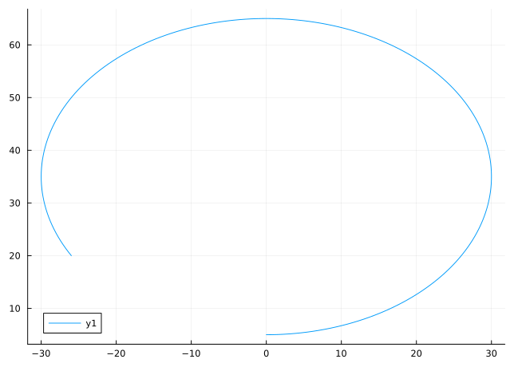

```julia
d = (R => 35, r=>30, ω => 2PI/120)
rt = subs.(rho(t), d...) # dots to broadcast and "splat"
plot(rt..., 0, 100)      # dots to splat to two variable
```

### 11.7.1 Polar coordinates

Polar coordinates are a special case of a representation. The are an alternate to Cartesian descriptions and use $(r,\theta)$ as an alternate to $(x,y)$. The translation is straightforward: $(x,y) = (r\cdot \cos(\theta), r\cdot\cos(\theta))$.

There isn’t much special support for polar coordinates within base `SymPy` or `Julia`. The `plot` function has a `projection=:polar` argument that plots polar plots where $r=r(\theta)$.

For example,

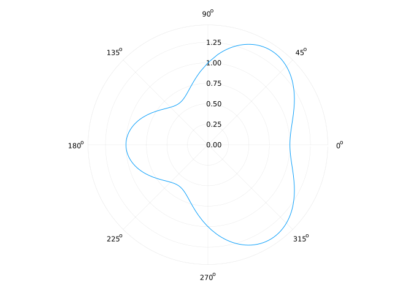

```julia
rho(theta) = 1 + cos(theta) * sin(theta)^2
@syms θ
plot(rho(θ), 0, 2pi; projection=:polar, legend=false)
```

### 11.7.2 Differential equations

A differential equation is an equation involving a variable, a function, and its derivatives. In the following we define an operator, using `Differential` to simplify the specification of the equation $y'(x) = y(x)$:

```julia
@syms x, u()
∂ = Differential(x)
ex = ∂(u(x)) ~ u(x)
```

\[ \frac{d}{d x} u{\left(x \right)} = u{\left(x \right)} \]

(The use of `Differential` just cleans up visually what can be achieved through `diff(u(x), x)` above.)

The `dsolve` function is then used to solve differential equations:

```julia
dsolve(ex)
```

\[ u{\left(x \right)} = C_{1} e^{x} \]

The constants come from integration. Initial conditions reduce the number of constants. These are specified to the `ics` keyword argument using a dictionary:

```julia
dsolve(ex, ics=Dict(u(0) => 3))
```

\[ u{\left(x \right)} = 3 e^{x} \]

The initial conditions can also involve constraints on derivatives, etc.

```julia
@syms x0::real y0::real v0::real γ::nonnegative 𝑔::real
@syms t::positive x u() v()
Dₜ = Differential(t)
D2ₜ = Dₜ ∘ Dₜ
eq₁ = Dₜ(Dₜ(u))(t) ~    - γ * Dₜ(u)(t)
eq₂ = Dₜ(Dₜ(v))(t) ~ -𝑔 - γ * Dₜ(v)(t)
```

\[ \frac{d^{2}}{d t^{2}} v{\left(t \right)} = - γ \frac{d}{d t} v{\left(t \right)} - 𝑔 \]

```julia
a1, a2 = dsolve.((eq₁(γ=>0), eq₂(γ=>0)), (u(t), v(t)))
tₓ = only(solve(x - rhs(a1), t)) # invert; only one solution
yₓ = rhs(a2)(t => tₓ)
```

\[ x - \frac{𝑔 \left(- C_{1} + x\right)^{2}}{2 C_{2}^{2}} \]

We can see the form of a parabola, with two parameters adjusting its shape related to the initial conditions. This is anticipated from physics.

Here, we specify initial values so that we can ultimately plot:

```julia
@syms α::real v₀::real
icx = Dict(u(0) => Sym(0), diff(u(t),t)(0) => v₀*cos(α))
icy = Dict(v(0) => Sym(0), diff(v(t),t)(0) => v₀*sin(α) )

a1 = dsolve(eq₁(γ => 0), u(t), ics=icx)
a2 = dsolve(eq₂(γ => 0), v(t), ics=icy)

tₓ = only(solve(x - rhs(a1), t)) # only one solution
yₓ = rhs(a2)(t => tₓ)
```

\[ \frac{x \sin{\left(α \right)}}{\cos{\left(α \right)}} - \frac{x^{2} 𝑔}{2 v₀^{2} \cos^{2}{\left(α \right)}} \]

If there is a positive $\gamma$, there will be drag and the formulas will change to reflect that.

```julia
𝑎1 = dsolve(eq₁, u(t), ics=icx)
𝑎2 = dsolve(eq₂, v(t), ics=icy)

𝑡ₓ = only(solve(x - rhs(𝑎1), t)) # only one solution
𝑦ₓ = rhs(𝑎2)(t => 𝑡ₓ)
```

\[ - \frac{𝑔 \log{\left(\frac{v₀ \cos{\left(α \right)}}{v₀ \cos{\left(α \right)} - x γ} \right)}}{γ^{2}} + \frac{v₀ γ \sin{\left(α \right)} + 𝑔}{γ^{2}} + \frac{\left(v₀ \cos{\left(α \right)} - x γ\right) \left(- v₀ γ \sin{\left(α \right)} - 𝑔\right)}{v₀ γ^{2} \cos{\left(α \right)}} \]

The difference can be visualized through plotting. The proper way to get the values for the constants is to specify numeric values in the initial conditions:

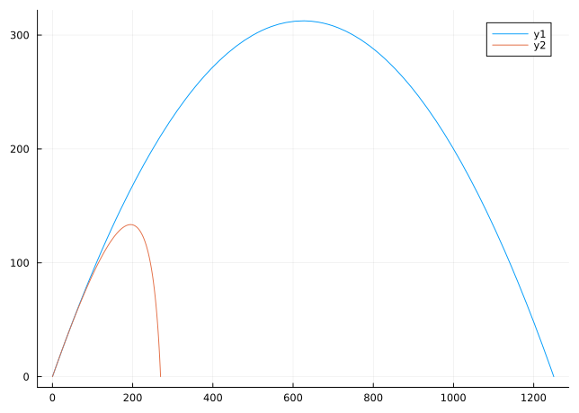

```julia
a = yₓ(𝑔 => 32, v₀ => 200, α => PI/4)
M = maximum(solve(a ~ 0))
plot(a, 0, N(M))

𝑎 = 𝑦ₓ(𝑔 => 32, v₀ => 200, α => PI/4, γ => 1//2)
M = nsolve(𝑎 ~ 0, 2*100*sqrt(2)-10) # avoid starting at asymptote
plot!(𝑎, 0, N(M))
```

[^1]: Other plotting packages can be used, of course, but there are a few recipes to easily plot `SymPy` expressions
[^2]: The `sympify` function takes an expression and makes it symbolic, which can be used to convert numbers to symbolic numbers or strings into variables.
[^3]: The alert reader may notice a different type face in the output below; one used for simpler symbolic expressions.
[^4]: We can’t use `=`, the mathematical indication of an equations, as that is used for assignment within `Julia`, as it is with most programming languages.
[^5]: There is a subtlety, `pi` is promoted to the symbolic value of `PI` before checking, as the floating point value associated to $\pi$, `3.141592653589793`, is not in the set.
[^6]: To run this example requires a newer version of `SymPy`.